# Transposable elements (TE) analysis in public datasets spanning preimplantation mouse development

Sara Formichetti

EMBL Rome  
sara.formichetti@embl.it

April 11th, 2023

# 1 Reading TE counts

The input files are:

- the output tables made by featureCounts (run in rule ‘count_on_TE’ of the Snakefile), which contain read counts of all repetitive elements (i.e. all repNames) for all samples
- the repetitive elements annotation ../../data/annotations/RepeatMasker_RepeatLibrary20140131_mm10.noGenes.noSimple.bed (converted to SAF format in rule of Snakefile) used for featureCounts command, that is used to retrieve repFamily and repClass for each repName. The annotation I chose is the most updated library to Nov2020 of rmsk, from which I removed ‘Simple repeats’ and ‘Low complexity regions’
- a table with total number of reads per sample in raw fastq files
- the samples’ table, containing metadata (i.e. stage)

# 2 Analysis at family level

## 2.1 FPKM for each family of Repetitive Elements

For each family of Repetitive Elements (in case of elements with no repFamily name or repFamilies belonging to more than one repClass I use repClass) I compute **FPKM** values, as follows: for each sample:

- I compute the sum of counts for all elements belonging to that repFamily
- I divide this sum by the total number of reads for that sample and multiply by 10⁶
- I divide this number by the total sum of lengths (in Kb) of the elements belonging to that repFamily –> FPKM
- When specified, **I subtract from each FPKM the total FPKM of all transposons belonging to the DNA repClass**

## 2.2 Heatmaps

The heatmaps are scaled by rows.

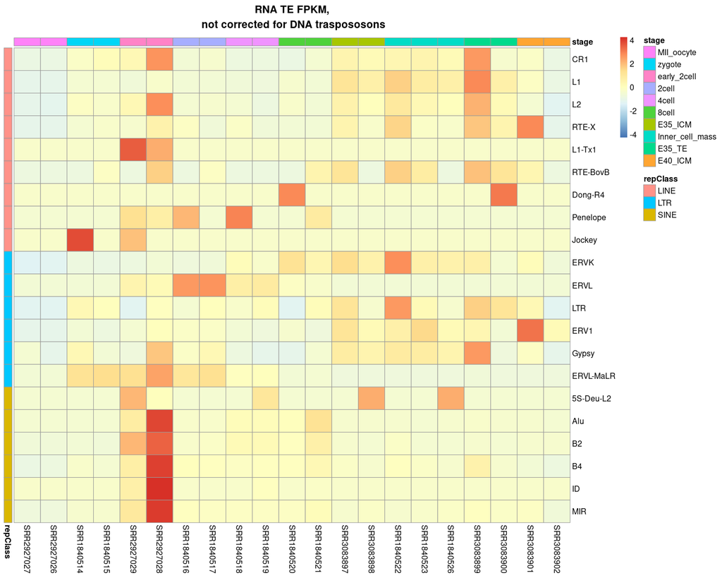

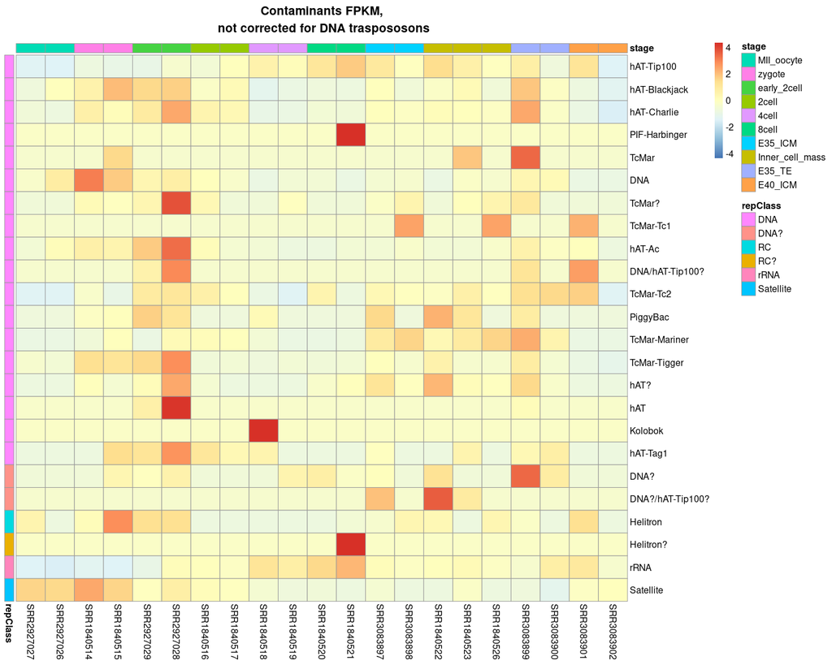

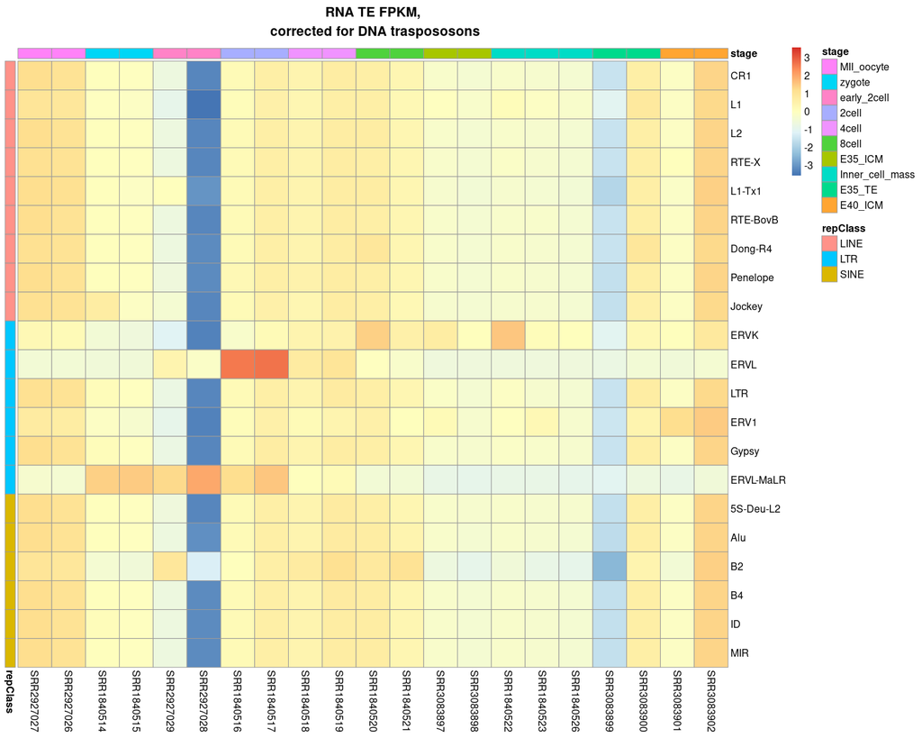

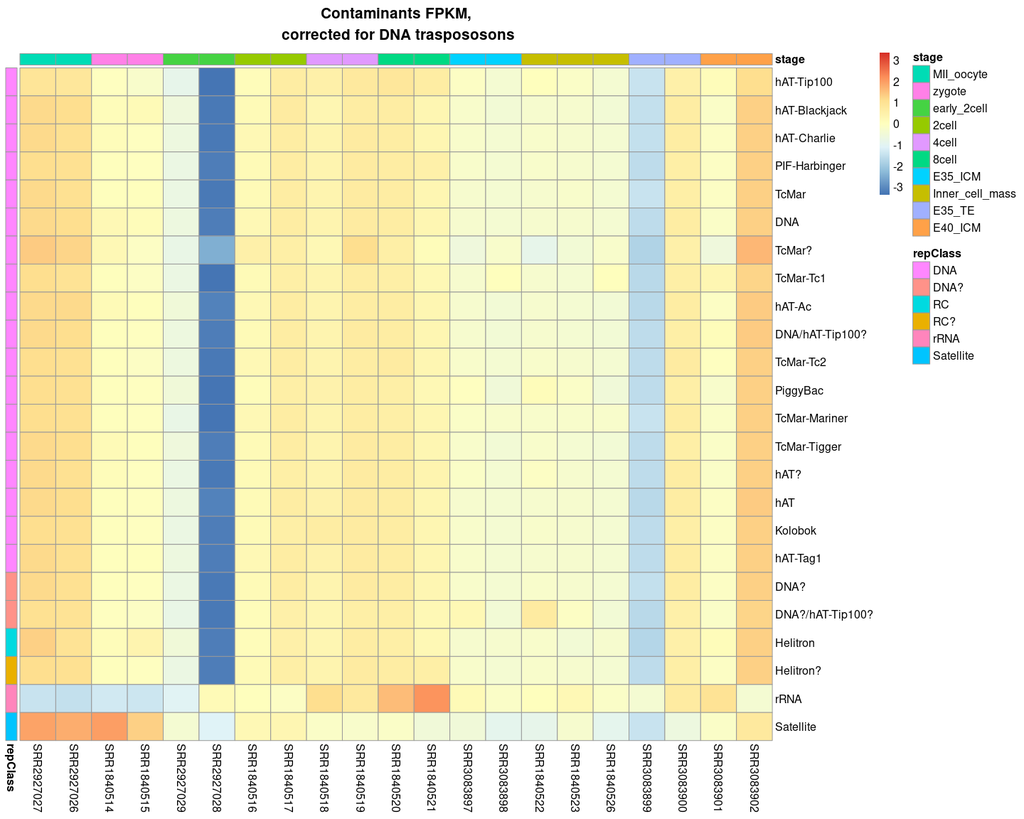

Based on above plots, I remove the early 2-cell sample SRR2927028 and replot.

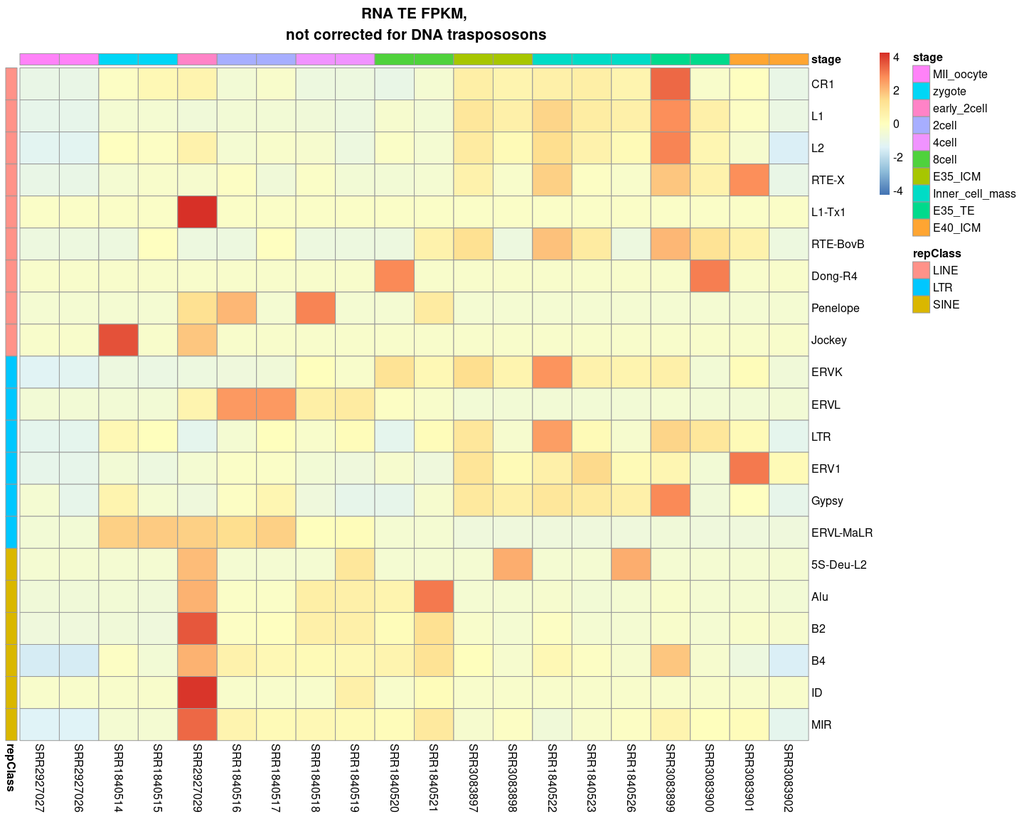

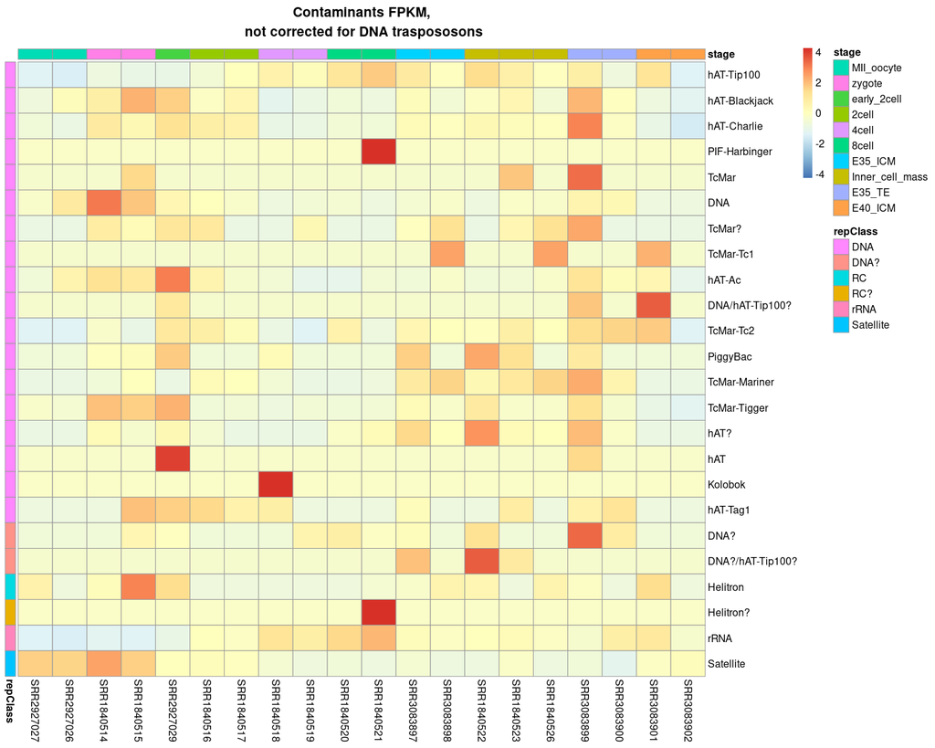

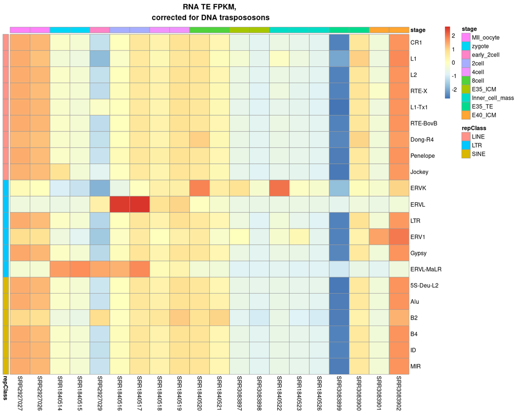

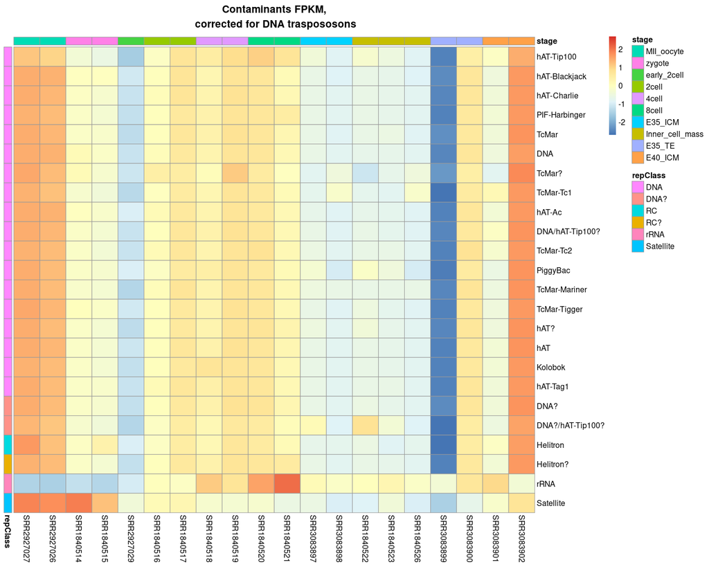

- Note that when correcting for DNA FPKM preimplantation embryonic stages get penalized compared to the oocyte i.e. oocyte FPKM values are overestimated.
- The only clear changes emerging above noise from the DNAFPKM-corrected heatmaps are the well-known ERVL upregulation at the late 2-cell stage and ERVL-MaLR upregulation from the zygote to the late 2-cell stage.

# 3 DE-Seq analysis of RNA transposons between subsequent preimplantation stages

I include the **FPKM of DNA repetitive elements as confounding factors in DESeq2 formula**.

Before running the Differential Expression analysis, the data are pre-filtered to remove all repetitive elements with < 10 reads among all samples.

I exclude the comparisons with the pre-EGA 2c stage because, after filtering bad samples, this stage includes only one biological replicate.

zygote vs MII oocyte

|  | baseMean | log2FoldChange | lfcSE | pvalue | padj | repName |
| --- | --- | --- | --- | --- | --- | --- |
| MTA_Mm | 4718.690175 | 3.1748847 | 0.3634000 | 0.0000000 | 0.0000000 | MTA_Mm |
| MuLV-int | 88.085682 | -2.6927603 | 0.3440952 | 0.0000000 | 0.0000000 | MuLV-int |
| ORR1C1-int | 111.147533 | -2.2180338 | 0.3099562 | 0.0000000 | 0.0000000 | ORR1C1-int |
| MERVL-int | 20685.665634 | 4.9953060 | 0.6845369 | 0.0000000 | 0.0000000 | MERVL-int |
| IAPEY5_I-int | 38.248711 | -3.2645676 | 0.4990741 | 0.0000000 | 0.0000000 | IAPEY5_I-int |
| L1Lx_I | 389.248277 | 4.1978004 | 0.6492919 | 0.0000000 | 0.0000000 | L1Lx_I |
| L1MdF_III | 559.210896 | 4.5415269 | 0.7368508 | 0.0000000 | 0.0000000 | L1MdF_III |
| IAPEY3-int | 83.711688 | -2.1674552 | 0.3871243 | 0.0000000 | 0.0000000 | IAPEY3-int |
| L1Lx_IV | 449.126064 | 2.3676198 | 0.4218458 | 0.0000000 | 0.0000000 | L1Lx_IV |
| MTE2b | 70.057237 | -1.6526674 | 0.3076528 | 0.0000000 | 0.0000000 | MTE2b |
| L1MdF_V | 444.474972 | 4.6627026 | 0.7802436 | 0.0000000 | 0.0000000 | L1MdF_V |
| L1_Mur2 | 295.244079 | 2.4685420 | 0.4784901 | 0.0000000 | 0.0000001 | L1_Mur2 |
| L1MdF_IV | 434.190199 | 4.5226672 | 0.8248892 | 0.0000000 | 0.0000002 | L1MdF_IV |
| L1MdV_III | 323.883563 | 2.8322766 | 0.5383078 | 0.0000000 | 0.0000002 | L1MdV_III |
| L1MdA_II | 620.303707 | 6.9047750 | 1.3593773 | 0.0000000 | 0.0000002 | L1MdA_II |
| L1MdTf_III | 704.552995 | 6.8377360 | 1.3522929 | 0.0000000 | 0.0000002 | L1MdTf_III |
| L1MdF_I | 337.797214 | 4.4354062 | 0.8339050 | 0.0000000 | 0.0000004 | L1MdF_I |
| L1MdFanc_II | 334.287560 | 6.4520012 | 1.3521244 | 0.0000001 | 0.0000012 | L1MdFanc_II |
| L1MdTf_II | 1552.234049 | 4.4308567 | 0.8810052 | 0.0000001 | 0.0000013 | L1MdTf_II |
| L1MdA_III | 614.797032 | 1.3842525 | 0.3028999 | 0.0000001 | 0.0000017 | L1MdA_III |
| L1MdGf_I | 625.823714 | 2.8070825 | 0.6065799 | 0.0000001 | 0.0000020 | L1MdGf_I |
| L1MdTf_I | 1497.502375 | 6.2833941 | 1.3696634 | 0.0000002 | 0.0000026 | L1MdTf_I |
| L1MdA_VII | 258.785943 | 6.2511344 | 1.3682401 | 0.0000002 | 0.0000028 | L1MdA_VII |
| L1MdFanc_I | 399.020299 | 4.8111655 | 1.0275653 | 0.0000003 | 0.0000044 | L1MdFanc_I |
| MMVL30-int | 467.134438 | -1.5616339 | 0.3827172 | 0.0000005 | 0.0000072 | MMVL30-int |
| RLTR4_MM-int | 291.627871 | -1.6920515 | 0.4230111 | 0.0000005 | 0.0000072 | RLTR4_MM-int |
| RLTR11A | 35.907051 | -1.8214194 | 0.4595071 | 0.0000005 | 0.0000072 | RLTR11A |
| LTR16C | 23.156056 | -2.0276201 | 0.5208260 | 0.0000008 | 0.0000097 | LTR16C |
| L1MdV_I | 317.427103 | 5.8539656 | 1.3686398 | 0.0000008 | 0.0000099 | L1MdV_I |
| L1MdA_I | 806.740430 | 5.5992849 | 1.3156553 | 0.0000010 | 0.0000125 | L1MdA_I |

[output cut: 70 more lines]

postEGA 2c vs zygote

|  | baseMean | log2FoldChange | lfcSE | pvalue | padj | repName |
| --- | --- | --- | --- | --- | --- | --- |
| MT2_Mm | 2751.765261 | 7.7193617 | 0.3699055 | 0.0000000 | 0.0000000 | MT2_Mm |
| ORR1A1-int | 1900.521786 | 4.9777258 | 0.2603529 | 0.0000000 | 0.0000000 | ORR1A1-int |
| ORR1A0 | 232.436518 | 6.3825652 | 0.3844886 | 0.0000000 | 0.0000000 | ORR1A0 |
| ORR1A0-int | 3477.346922 | 6.7457366 | 0.4195310 | 0.0000000 | 0.0000000 | ORR1A0-int |
| MER89 | 142.145471 | 6.4620583 | 0.4522609 | 0.0000000 | 0.0000000 | MER89 |
| MERVL-int | 20685.665634 | 6.6343849 | 0.5094547 | 0.0000000 | 0.0000000 | MERVL-int |
| ORR1A1 | 175.556491 | 4.4024824 | 0.3548656 | 0.0000000 | 0.0000000 | ORR1A1 |
| RLTR19 | 62.789268 | 4.1033571 | 0.3428447 | 0.0000000 | 0.0000000 | RLTR19 |
| MERVL_2A-int | 407.117166 | 4.3973980 | 0.3767672 | 0.0000000 | 0.0000000 | MERVL_2A-int |
| RLTR10C | 101.396137 | 3.4717641 | 0.3225810 | 0.0000000 | 0.0000000 | RLTR10C |
| ORR1A2 | 142.223361 | 2.3708493 | 0.2388593 | 0.0000000 | 0.0000000 | ORR1A2 |
| MMETn-int | 4901.889603 | 3.5484031 | 0.3833496 | 0.0000000 | 0.0000000 | MMETn-int |
| ORR1A2-int | 911.778661 | 2.4724029 | 0.2711598 | 0.0000000 | 0.0000000 | ORR1A2-int |
| MT2C_Mm | 76.176941 | 3.3189318 | 0.3782831 | 0.0000000 | 0.0000000 | MT2C_Mm |
| RLTR4_Mm | 76.552341 | 3.3942138 | 0.4073431 | 0.0000000 | 0.0000000 | RLTR4_Mm |
| MT2B2 | 70.389907 | 2.8958527 | 0.3587588 | 0.0000000 | 0.0000000 | MT2B2 |
| ERVB4_2-LTR_MM | 87.673552 | 3.9793603 | 0.5252278 | 0.0000000 | 0.0000000 | ERVB4_2-LTR_MM |
| IAPLTR1_Mm | 89.566333 | 3.1599362 | 0.4254772 | 0.0000000 | 0.0000000 | IAPLTR1_Mm |
| LTRIS_Mus | 38.222974 | 3.1481461 | 0.4416926 | 0.0000000 | 0.0000000 | LTRIS_Mus |
| IAPEY4_I-int | 74.817995 | 3.2864098 | 0.4717299 | 0.0000000 | 0.0000000 | IAPEY4_I-int |
| ORR1A4-int | 278.120957 | 2.5967988 | 0.3636658 | 0.0000000 | 0.0000000 | ORR1A4-int |
| L1MB5 | 152.030760 | -2.1875000 | 0.3073125 | 0.0000000 | 0.0000000 | L1MB5 |
| ERVL-B4-int | 55.858512 | 2.7585791 | 0.4077091 | 0.0000000 | 0.0000000 | ERVL-B4-int |
| RMER21B | 43.143554 | -3.7754388 | 0.5881516 | 0.0000000 | 0.0000000 | RMER21B |
| MT2B | 51.983232 | 2.0765150 | 0.3097325 | 0.0000000 | 0.0000000 | MT2B |
| RMER17A-int | 70.638756 | -3.0620216 | 0.4803432 | 0.0000000 | 0.0000000 | RMER17A-int |
| MMERVK10C-int | 591.716852 | 1.7569815 | 0.2682171 | 0.0000000 | 0.0000000 | MMERVK10C-int |
| MTC-int | 215.893874 | -1.9299439 | 0.2964916 | 0.0000000 | 0.0000000 | MTC-int |
| IAPLTR1a_Mm | 27.292144 | 3.4265820 | 0.5651361 | 0.0000000 | 0.0000000 | IAPLTR1a_Mm |
| IAPLTR2_Mm | 24.060225 | 3.0577580 | 0.4941427 | 0.0000000 | 0.0000000 | IAPLTR2_Mm |

[output cut: 171 more lines]

4c vs postEGA 2c

|  | baseMean | log2FoldChange | lfcSE | pvalue | padj | repName |
| --- | --- | --- | --- | --- | --- | --- |
| RLTR45-int | 6971.091058 | 3.7982689 | 0.3788471 | 0.0000000 | 0.0000000 | RLTR45-int |
| ERVB4_2-I_MM | 776.196549 | 3.9354747 | 0.4511096 | 0.0000000 | 0.0000000 | ERVB4_2-I_MM |
| RLTR13B1 | 114.826368 | 3.2281961 | 0.4831377 | 0.0000000 | 0.0000000 | RLTR13B1 |
| L1MdV_I | 317.427103 | 1.7052351 | 0.2632274 | 0.0000000 | 0.0000000 | L1MdV_I |
| RLTR40 | 239.861664 | -2.3047326 | 0.5528352 | 0.0000000 | 0.0000005 | RLTR40 |
| MMERVK10C-int | 591.716852 | 1.2680981 | 0.2567477 | 0.0000000 | 0.0000018 | MMERVK10C-int |
| MMETn-int | 4901.889603 | 1.6461648 | 0.3636484 | 0.0000000 | 0.0000018 | MMETn-int |
| Lx5b | 172.899740 | -1.1597402 | 0.2577771 | 0.0000004 | 0.0000180 | Lx5b |
| L1MdA_II | 620.303707 | 1.0857567 | 0.2417073 | 0.0000006 | 0.0000210 | L1MdA_II |
| L1MB5 | 152.030760 | -1.7033032 | 0.4499506 | 0.0000006 | 0.0000222 | L1MB5 |
| L1MdTf_I | 1497.502375 | 1.2397196 | 0.2944238 | 0.0000012 | 0.0000361 | L1MdTf_I |
| ORR1D1-int | 29.967482 | -1.4800033 | 0.3949413 | 0.0000026 | 0.0000738 | ORR1D1-int |
| L1MdGf_I | 625.823714 | 1.0759973 | 0.2704345 | 0.0000055 | 0.0001460 | L1MdGf_I |
| IAPLTR1_Mm | 89.566333 | 1.1416444 | 0.2940116 | 0.0000065 | 0.0001609 | IAPLTR1_Mm |
| B1_Mus2 | 66.076384 | 1.6621129 | 0.5442685 | 0.0000113 | 0.0002600 | B1_Mus2 |
| L1MdTf_II | 1552.234049 | 1.1513379 | 0.3100064 | 0.0000124 | 0.0002659 | L1MdTf_II |
| RLTR45 | 153.507229 | 1.4152659 | 0.4532023 | 0.0000315 | 0.0006366 | RLTR45 |
| B1_Mm | 56.581553 | 1.6255340 | 0.6176908 | 0.0000483 | 0.0009172 | B1_Mm |
| RLTR50B | 18.024782 | -1.5921703 | 0.5966050 | 0.0000507 | 0.0009172 | RLTR50B |
| RLTR13B2 | 48.188671 | 1.4775867 | 0.5420928 | 0.0000745 | 0.0012693 | RLTR13B2 |
| Lx3B | 79.236226 | -1.0434576 | 0.3141605 | 0.0000775 | 0.0012693 | Lx3B |
| MuLV-int | 88.085682 | 1.0495028 | 0.3336758 | 0.0001389 | 0.0021714 | MuLV-int |
| B2_Mm2 | 544.932679 | 1.2498989 | 0.4352508 | 0.0001458 | 0.0021813 | B2_Mm2 |
| RLTR6B_Mm | 27.211544 | -1.2106955 | 0.4320001 | 0.0002116 | 0.0030326 | RLTR6B_Mm |
| ETnERV2-int | 242.978125 | 0.9690200 | 0.3148733 | 0.0002306 | 0.0031732 | ETnERV2-int |
| B2_Mm1a | 1713.375648 | 1.2569916 | 0.4988161 | 0.0003635 | 0.0048088 | B2_Mm1a |
| B1_Mus1 | 68.244099 | 1.4043920 | 0.6488254 | 0.0004078 | 0.0051961 | B1_Mus1 |
| RLTR4_MM-int | 291.627871 | 0.9415244 | 0.3274280 | 0.0004850 | 0.0057353 | RLTR4_MM-int |
| MTE-int | 57.013055 | -0.9784701 | 0.3459007 | 0.0004917 | 0.0057353 | MTE-int |
| Lx2B2 | 246.173358 | -0.6827324 | 0.2188274 | 0.0005002 | 0.0057353 | Lx2B2 |
| B2_Mm1t | 1112.751367 | 1.1564656 | 0.4777283 | 0.0007315 | 0.0080843 | B2_Mm1t |
| Lx9 | 334.311664 | -0.5632913 | 0.1814255 | 0.0007520 | 0.0080843 | Lx9 |
| RMER3D-int | 72.071743 | -1.1095824 | 0.4794491 | 0.0011556 | 0.0120458 | RMER3D-int |
| RMER17A-int | 70.638756 | -1.2834538 | 0.7199855 | 0.0013870 | 0.0136424 | RMER17A-int |
| RLTR31B2 | 15.518438 | 1.0913014 | 0.4809917 | 0.0013880 | 0.0136424 | RLTR31B2 |
| ETnERV3-int | 290.412206 | 1.0197536 | 0.4290414 | 0.0014621 | 0.0137905 | ETnERV3-int |
| MTE2b | 70.057237 | 0.7042158 | 0.2546597 | 0.0014833 | 0.0137905 | MTE2b |
| IAPEz-int | 2443.254944 | 0.8312914 | 0.3231966 | 0.0017461 | 0.0158067 | IAPEz-int |
| RLTR13E | 18.151547 | 1.0416543 | 0.4643488 | 0.0018255 | 0.0161016 | RLTR13E |
| Lx7 | 578.885557 | -0.6173394 | 0.2225350 | 0.0018800 | 0.0161676 | Lx7 |
| MLT2B1 | 9.835016 | 1.1709865 | 0.6265862 | 0.0020359 | 0.0170817 | MLT2B1 |
| L1MdA_I | 806.740430 | 0.8386061 | 0.3380946 | 0.0021999 | 0.0180185 | L1MdA_I |
| RLTR13D5 | 22.784002 | -1.1026097 | 0.5557740 | 0.0023277 | 0.0186214 | RLTR13D5 |
| RMER19B2 | 81.220106 | -0.7277272 | 0.2983642 | 0.0035634 | 0.0278594 | RMER19B2 |
| ORR1D2-int | 23.826408 | -0.9721821 | 0.4723027 | 0.0036526 | 0.0279221 | ORR1D2-int |
| L1MdTf_III | 704.552995 | 0.5316668 | 0.2025054 | 0.0037706 | 0.0281974 | L1MdTf_III |
| RLTR13A3 | 22.969320 | 0.9859998 | 0.5093229 | 0.0043436 | 0.0317917 | RLTR13A3 |
| MT2_Mm | 2751.765261 | -0.7522310 | 0.3246770 | 0.0045611 | 0.0326876 | MT2_Mm |
| MTB_Mm-int | 183.816377 | -0.9566398 | 0.4924474 | 0.0048924 | 0.0343463 | MTB_Mm-int |
| RLTR13A2 | 34.274037 | 0.9877493 | 0.5450320 | 0.0052953 | 0.0364314 | RLTR13A2 |
| RLTR13G | 50.979141 | 0.8719719 | 0.4237557 | 0.0055264 | 0.0372764 | RLTR13G |
| L1_Mur3 | 370.991728 | -0.4696906 | 0.1874709 | 0.0063000 | 0.0415102 | L1_Mur3 |
| IAPEY2_LTR | 9.759280 | -0.9874550 | 0.5884897 | 0.0063955 | 0.0415102 | IAPEY2_LTR |
| MTC | 116.477847 | 0.5494742 | 0.2316232 | 0.0073398 | 0.0467569 | MTC |
| L1MdN_I | 122.046120 | 0.7479295 | 0.3534188 | 0.0076255 | 0.0473359 | L1MdN_I |
| Lx8b | 170.082455 | -0.5344689 | 0.2255294 | 0.0077058 | 0.0473359 | Lx8b |
| Lx3_Mus | 216.577970 | -0.5557870 | 0.2374948 | 0.0078593 | 0.0474318 | Lx3_Mus |
| L1MdF_I | 337.797214 | 0.5010357 | 0.2116557 | 0.0085036 | 0.0504352 | L1MdF_I |
| L1MA8 | 14.133320 | -0.8611588 | 0.5219619 | 0.0121134 | 0.0706271 | L1MA8 |
| L1M2 | 127.275931 | -0.5370950 | 0.2489961 | 0.0133067 | 0.0756890 | L1M2 |
| L1MB7 | 56.370275 | -0.6687592 | 0.3365540 | 0.0134216 | 0.0756890 | L1MB7 |
| L1MdF_V | 444.474972 | -0.6343722 | 0.3146800 | 0.0140214 | 0.0773669 | L1MdF_V |
| ETnERV-int | 552.777898 | 0.6564529 | 0.3314422 | 0.0141760 | 0.0773669 | ETnERV-int |
| MYSERV16_I-int | 114.323833 | -0.7105199 | 0.3757239 | 0.0143938 | 0.0773669 | MYSERV16_I-int |
| MER21C | 18.853208 | 0.7459620 | 0.4113115 | 0.0148281 | 0.0784750 | MER21C |
| RLTR6-int | 255.580418 | -0.5264734 | 0.2492418 | 0.0153132 | 0.0798142 | RLTR6-int |
| L1MdGf_II | 250.695268 | 0.4592427 | 0.2115178 | 0.0158204 | 0.0812273 | L1MdGf_II |
| ORR1E | 67.062404 | -0.5691244 | 0.2841430 | 0.0176193 | 0.0879944 | ORR1E |
| MMVL30-int | 467.134438 | 0.5853114 | 0.2953837 | 0.0176500 | 0.0879944 | MMVL30-int |
| MTB-int | 163.363455 | -0.5950580 | 0.3091369 | 0.0194941 | 0.0944711 | MTB-int |
| RLTR14 | 20.044601 | -0.7066176 | 0.4044085 | 0.0194984 | 0.0944711 | RLTR14 |
| MMERVK9C_I-int | 274.204475 | 0.5790517 | 0.2993829 | 0.0200386 | 0.0957397 | MMERVK9C_I-int |
| MERV1_I-int | 42.109602 | 0.7097449 | 0.4195628 | 0.0213747 | 0.0994035 | MERV1_I-int |
| MLT1C2 | 13.604781 | 0.7426714 | 0.4628636 | 0.0217651 | 0.0994035 | MLT1C2 |
| IAPEY5_I-int | 38.248711 | -0.8099952 | 0.6288214 | 0.0218691 | 0.0994035 | IAPEY5_I-int |
| RLTR13C2 | 42.982150 | 0.7610140 | 0.4922981 | 0.0219612 | 0.0994035 | RLTR13C2 |

8c vs 4c

|  | baseMean | log2FoldChange | lfcSE | pvalue | padj | repName |
| --- | --- | --- | --- | --- | --- | --- |
| ORR1A1-int | 1900.52179 | -1.3051212 | 0.2356416 | 0.0000000 | 0.0000014 | ORR1A1-int |
| MT2_Mm | 2751.76526 | -1.5351493 | 0.3188438 | 0.0000001 | 0.0000137 | MT2_Mm |
| MERVL_2A-int | 407.11717 | -1.5263408 | 0.3228707 | 0.0000001 | 0.0000138 | MERVL_2A-int |
| ORR1A2-int | 911.77866 | -1.2357528 | 0.2538978 | 0.0000002 | 0.0000138 | ORR1A2-int |
| MTA_Mm | 4718.69018 | -1.3021702 | 0.2995038 | 0.0000013 | 0.0000905 | MTA_Mm |
| MTB-int | 163.36346 | -1.3976977 | 0.3303542 | 0.0000015 | 0.0000905 | MTB-int |
| ORR1A0-int | 3477.34692 | -1.4799727 | 0.3644767 | 0.0000021 | 0.0001086 | ORR1A0-int |
| RLTR19 | 62.78927 | -1.0519783 | 0.2618174 | 0.0000071 | 0.0003161 | RLTR19 |
| ERVL-B4-int | 55.85851 | -1.3607430 | 0.3694182 | 0.0000109 | 0.0004349 | ERVL-B4-int |
| ORR1A0 | 232.43652 | -1.0116554 | 0.2670929 | 0.0000159 | 0.0005530 | ORR1A0 |
| MERVL-int | 20685.66563 | -1.4836103 | 0.4440670 | 0.0000170 | 0.0005530 | MERVL-int |
| ORR1A1 | 175.55649 | -0.9226392 | 0.3177807 | 0.0002070 | 0.0061761 | ORR1A1 |
| MTA_Mm-int | 52698.16541 | -1.2685936 | 0.5180822 | 0.0002271 | 0.0062530 | MTA_Mm-int |
| ETnERV2-int | 242.97812 | 0.9213423 | 0.3332046 | 0.0002918 | 0.0074611 | ETnERV2-int |
| RLTR13B1 | 114.82637 | 1.0439464 | 0.4015150 | 0.0003540 | 0.0084487 | RLTR13B1 |
| MT-int | 1264.50014 | -1.1360374 | 0.5439560 | 0.0006503 | 0.0145496 | MT-int |
| IAPEy-int | 51.29326 | -1.0173407 | 0.5040597 | 0.0011280 | 0.0237544 | IAPEy-int |
| MER89 | 142.14547 | -0.7098314 | 0.3315788 | 0.0015529 | 0.0308853 | MER89 |
| ORR1A2 | 142.22336 | -0.5477334 | 0.2600159 | 0.0018265 | 0.0344158 | ORR1A2 |
| RLTR13D5 | 22.78400 | 0.9657992 | 0.6006278 | 0.0022027 | 0.0373115 | RLTR13D5 |
| MTE2b-int | 14.99656 | -0.9200639 | 0.7061419 | 0.0022807 | 0.0373115 | MTE2b-int |
| RMER21A | 17.61951 | -0.9219355 | 0.5249102 | 0.0022929 | 0.0373115 | RMER21A |
| Lx5 | 315.18219 | -0.4224663 | 0.2159796 | 0.0032362 | 0.0496516 | Lx5 |
| MMERVK9C_I-int | 274.20447 | 0.6671374 | 0.3628319 | 0.0033901 | 0.0496516 | MMERVK9C_I-int |
| MER21C | 18.85321 | -0.8392735 | 0.5056225 | 0.0034673 | 0.0496516 | MER21C |
| RLTR45 | 153.50723 | 0.7867008 | 0.4739450 | 0.0040179 | 0.0553237 | RLTR45 |
| Lx2B2 | 246.17336 | -0.4934011 | 0.2781040 | 0.0048600 | 0.0644395 | Lx2B2 |
| MTC-int | 215.89387 | -0.6139037 | 0.3868811 | 0.0066852 | 0.0850852 | MTC-int |
| L1VL1 | 28.60853 | 0.7486588 | 0.5385398 | 0.0069158 | 0.0850852 | L1VL1 |
| ERVB4_2-I_MM | 776.19655 | 0.6875097 | 0.4625735 | 0.0071510 | 0.0850852 | ERVB4_2-I_MM |
| RLTR10C | 101.39614 | -0.4796884 | 0.2944120 | 0.0073677 | 0.0850852 | RLTR10C |
| RLTR21 | 90.60935 | -0.6716483 | 0.4678407 | 0.0082054 | 0.0917984 | RLTR21 |
| L1MdA_V | 111.82989 | 0.5901619 | 0.3989626 | 0.0089737 | 0.0973515 | L1MdA_V |

ICM vs 8c

|  | baseMean | log2FoldChange | lfcSE | pvalue | padj | repName |
| --- | --- | --- | --- | --- | --- | --- |
| ORR1A1-int | 1900.521786 | -3.5395176 | 0.2492475 | 0.0000000 | 0.0000000 | ORR1A1-int |
| L1Lx_I | 389.248277 | 2.0606073 | 0.1534435 | 0.0000000 | 0.0000000 | L1Lx_I |
| MT2_Mm | 2751.765261 | -4.3824610 | 0.3495308 | 0.0000000 | 0.0000000 | MT2_Mm |
| MTA_Mm | 4718.690175 | -3.8670612 | 0.3188344 | 0.0000000 | 0.0000000 | MTA_Mm |
| MER89 | 142.145471 | -4.6888688 | 0.4003604 | 0.0000000 | 0.0000000 | MER89 |
| ORR1A0 | 232.436518 | -3.6086211 | 0.3114285 | 0.0000000 | 0.0000000 | ORR1A0 |
| ORR1A1 | 175.556491 | -3.5313781 | 0.3455264 | 0.0000000 | 0.0000000 | ORR1A1 |
| ORR1A2-int | 911.778661 | -2.6193819 | 0.2729686 | 0.0000000 | 0.0000000 | ORR1A2-int |
| MERVL-int | 20685.665634 | -4.6115561 | 0.4820897 | 0.0000000 | 0.0000000 | MERVL-int |
| RLTR10C | 101.396137 | -2.7754855 | 0.3031859 | 0.0000000 | 0.0000000 | RLTR10C |
| MMERVK10C-int | 591.716852 | -2.3401636 | 0.2579117 | 0.0000000 | 0.0000000 | MMERVK10C-int |
| MTA_Mm-int | 52698.165407 | -4.6237144 | 0.5304166 | 0.0000000 | 0.0000000 | MTA_Mm-int |
| MT-int | 1264.500140 | -4.9854033 | 0.5752170 | 0.0000000 | 0.0000000 | MT-int |
| Lx3_Mus | 216.577970 | 1.9854783 | 0.2279844 | 0.0000000 | 0.0000000 | Lx3_Mus |
| L1MdFanc_II | 334.287560 | 1.8840967 | 0.2161452 | 0.0000000 | 0.0000000 | L1MdFanc_II |
| Lx2B2 | 246.173358 | 1.8834812 | 0.2165311 | 0.0000000 | 0.0000000 | Lx2B2 |
| MT2C_Mm | 76.176941 | -3.0815274 | 0.3711341 | 0.0000000 | 0.0000000 | MT2C_Mm |
| L1MdF_I | 337.797214 | 1.6279448 | 0.1968726 | 0.0000000 | 0.0000000 | L1MdF_I |
| ORR1A2 | 142.223361 | -1.9219733 | 0.2378979 | 0.0000000 | 0.0000000 | ORR1A2 |
| L1MdA_VI | 253.849184 | 1.9906858 | 0.2507725 | 0.0000000 | 0.0000000 | L1MdA_VI |
| B1_Mus2 | 66.076384 | -4.0498448 | 0.5371313 | 0.0000000 | 0.0000000 | B1_Mus2 |
| RLTR19 | 62.789268 | -2.6313439 | 0.3536060 | 0.0000000 | 0.0000000 | RLTR19 |
| Lx9 | 334.311664 | 1.3259854 | 0.1696278 | 0.0000000 | 0.0000000 | Lx9 |
| L1MdMus_I | 180.467799 | 1.8734312 | 0.2447943 | 0.0000000 | 0.0000000 | L1MdMus_I |
| B1_Mm | 56.581553 | -4.5178566 | 0.6217518 | 0.0000000 | 0.0000000 | B1_Mm |
| L1MdGf_II | 250.695268 | 1.4320315 | 0.1900709 | 0.0000000 | 0.0000000 | L1MdGf_II |
| L1MdA_III | 614.797032 | 1.3550822 | 0.1827875 | 0.0000000 | 0.0000000 | L1MdA_III |
| L1MdF_III | 559.210896 | 1.4817156 | 0.2063725 | 0.0000000 | 0.0000000 | L1MdF_III |
| Lx8b | 170.082455 | 1.5747698 | 0.2217411 | 0.0000000 | 0.0000000 | Lx8b |
| B3 | 175.338095 | -2.2411723 | 0.3285018 | 0.0000000 | 0.0000000 | B3 |

[output cut: 180 more lines]

E3.5 ICM vs 8c

|  | baseMean | log2FoldChange | lfcSE | pvalue | padj | repName |
| --- | --- | --- | --- | --- | --- | --- |
| ORR1A1-int | 1900.521786 | -3.5178290 | 0.2723408 | 0.0000000 | 0.0000000 | ORR1A1-int |
| L1Lx_I | 389.248277 | 2.0391225 | 0.1640201 | 0.0000000 | 0.0000000 | L1Lx_I |
| MT2_Mm | 2751.765261 | -4.2664897 | 0.3812299 | 0.0000000 | 0.0000000 | MT2_Mm |
| MTA_Mm | 4718.690175 | -3.8029050 | 0.3486596 | 0.0000000 | 0.0000000 | MTA_Mm |
| MER89 | 142.145471 | -4.5079849 | 0.4160186 | 0.0000000 | 0.0000000 | MER89 |
| ORR1A0 | 232.436518 | -3.6313319 | 0.3396070 | 0.0000000 | 0.0000000 | ORR1A0 |
| ORR1A1 | 175.556491 | -3.4649535 | 0.3759799 | 0.0000000 | 0.0000000 | ORR1A1 |
| ORR1A2-int | 911.778661 | -2.6213029 | 0.2977994 | 0.0000000 | 0.0000000 | ORR1A2-int |
| RLTR10C | 101.396137 | -2.8064775 | 0.3295448 | 0.0000000 | 0.0000000 | RLTR10C |
| MERVL-int | 20685.665634 | -4.5013863 | 0.5266428 | 0.0000000 | 0.0000000 | MERVL-int |
| MMERVK10C-int | 591.716852 | -2.3401622 | 0.2805079 | 0.0000000 | 0.0000000 | MMERVK10C-int |
| MTA_Mm-int | 52698.165407 | -4.5779850 | 0.5789962 | 0.0000000 | 0.0000000 | MTA_Mm-int |
| Lx2B2 | 246.173358 | 1.8569914 | 0.2305755 | 0.0000000 | 0.0000000 | Lx2B2 |
| L1MdFanc_II | 334.287560 | 1.8633329 | 0.2322731 | 0.0000000 | 0.0000000 | L1MdFanc_II |
| Lx3_Mus | 216.577970 | 1.9288102 | 0.2432740 | 0.0000000 | 0.0000000 | Lx3_Mus |
| MT2C_Mm | 76.176941 | -3.0213769 | 0.4020140 | 0.0000000 | 0.0000000 | MT2C_Mm |
| MT-int | 1264.500140 | -4.6882804 | 0.6265570 | 0.0000000 | 0.0000000 | MT-int |
| L1MdF_I | 337.797214 | 1.6256484 | 0.2116517 | 0.0000000 | 0.0000000 | L1MdF_I |
| ORR1A2 | 142.223361 | -1.8893504 | 0.2557701 | 0.0000000 | 0.0000000 | ORR1A2 |
| L1MdA_VI | 253.849184 | 1.9530674 | 0.2691012 | 0.0000000 | 0.0000000 | L1MdA_VI |
| RLTR19 | 62.789268 | -2.5944812 | 0.3733116 | 0.0000000 | 0.0000000 | RLTR19 |
| L1MdGf_II | 250.695268 | 1.4846776 | 0.2039187 | 0.0000000 | 0.0000000 | L1MdGf_II |
| B1_Mm | 56.581553 | -4.5969555 | 0.6861965 | 0.0000000 | 0.0000000 | B1_Mm |
| B1_Mus2 | 66.076384 | -3.8935332 | 0.5898704 | 0.0000000 | 0.0000000 | B1_Mus2 |
| Lx9 | 334.311664 | 1.3042788 | 0.1815927 | 0.0000000 | 0.0000000 | Lx9 |
| L1MdMus_I | 180.467799 | 1.8387496 | 0.2619862 | 0.0000000 | 0.0000000 | L1MdMus_I |
| L1MdA_III | 614.797032 | 1.3473939 | 0.1973259 | 0.0000000 | 0.0000000 | L1MdA_III |
| L1MdF_III | 559.210896 | 1.4993155 | 0.2227151 | 0.0000000 | 0.0000000 | L1MdF_III |
| Lx8b | 170.082455 | 1.5568347 | 0.2364598 | 0.0000000 | 0.0000000 | Lx8b |
| MT2B | 51.983232 | -2.0807214 | 0.3275341 | 0.0000000 | 0.0000000 | MT2B |

[output cut: 163 more lines]

E3.5 TE vs 8c

|  | baseMean | log2FoldChange | lfcSE | pvalue | padj | repName |
| --- | --- | --- | --- | --- | --- | --- |
| ORR1A1-int | 1900.521786 | -4.7041095 | 0.2825015 | 0.0000000 | 0.0000000 | ORR1A1-int |
| L1Lx_I | 389.248277 | 2.2106431 | 0.1669066 | 0.0000000 | 0.0000000 | L1Lx_I |
| MT2_Mm | 2751.765261 | -4.5328530 | 0.3902952 | 0.0000000 | 0.0000000 | MT2_Mm |
| ORR1A0 | 232.436518 | -3.7150916 | 0.3456127 | 0.0000000 | 0.0000000 | ORR1A0 |
| MTA_Mm | 4718.690175 | -3.5305894 | 0.3554559 | 0.0000000 | 0.0000000 | MTA_Mm |
| MER89 | 142.145471 | -3.9533340 | 0.3979268 | 0.0000000 | 0.0000000 | MER89 |
| ORR1A2-int | 911.778661 | -2.8323430 | 0.3030726 | 0.0000000 | 0.0000000 | ORR1A2-int |
| ORR1A0-int | 3477.346922 | -3.9523085 | 0.4428751 | 0.0000000 | 0.0000000 | ORR1A0-int |
| MERVL-int | 20685.665634 | -4.7420982 | 0.5353733 | 0.0000000 | 0.0000000 | MERVL-int |
| Lx3_Mus | 216.577970 | 2.2089174 | 0.2485603 | 0.0000000 | 0.0000000 | Lx3_Mus |
| ORR1A1 | 175.556491 | -3.2537523 | 0.3753098 | 0.0000000 | 0.0000000 | ORR1A1 |
| L1MdF_I | 337.797214 | 1.8831250 | 0.2168909 | 0.0000000 | 0.0000000 | L1MdF_I |
| L1MdFanc_II | 334.287560 | 2.0406685 | 0.2376803 | 0.0000000 | 0.0000000 | L1MdFanc_II |
| Lx9 | 334.311664 | 1.5569483 | 0.1849953 | 0.0000000 | 0.0000000 | Lx9 |
| RLTR10C | 101.396137 | -2.6174756 | 0.3261872 | 0.0000000 | 0.0000000 | RLTR10C |
| MT2C_Mm | 76.176941 | -3.2520200 | 0.4150476 | 0.0000000 | 0.0000000 | MT2C_Mm |
| RLTR19 | 62.789268 | -3.1928626 | 0.4168856 | 0.0000000 | 0.0000000 | RLTR19 |
| Lx2B2 | 246.173358 | 1.8607099 | 0.2346220 | 0.0000000 | 0.0000000 | Lx2B2 |
| MMERVK10C-int | 591.716852 | -2.1672468 | 0.2833196 | 0.0000000 | 0.0000000 | MMERVK10C-int |
| L1MdMus_I | 180.467799 | 2.0184685 | 0.2683236 | 0.0000000 | 0.0000000 | L1MdMus_I |
| L1MdA_VI | 253.849184 | 2.0656579 | 0.2756408 | 0.0000000 | 0.0000000 | L1MdA_VI |
| MT2B2 | 70.389907 | -2.9287072 | 0.4191259 | 0.0000000 | 0.0000000 | MT2B2 |
| L1MdA_III | 614.797032 | 1.4842242 | 0.2020152 | 0.0000000 | 0.0000000 | L1MdA_III |
| L1MdGf_II | 250.695268 | 1.4853227 | 0.2088434 | 0.0000000 | 0.0000000 | L1MdGf_II |
| RLTR13B1 | 114.826368 | -2.9641667 | 0.4454218 | 0.0000000 | 0.0000000 | RLTR13B1 |
| MT-int | 1264.500140 | -4.2285488 | 0.6445132 | 0.0000000 | 0.0000000 | MT-int |
| Lx2 | 359.521136 | 2.1093067 | 0.3067504 | 0.0000000 | 0.0000000 | Lx2 |
| B2_Mm2 | 544.932679 | -3.3196940 | 0.5047690 | 0.0000000 | 0.0000000 | B2_Mm2 |
| Lx8b | 170.082455 | 1.6784836 | 0.2413037 | 0.0000000 | 0.0000000 | Lx8b |
| B1_Mus2 | 66.076384 | -3.8768691 | 0.5983954 | 0.0000000 | 0.0000000 | B1_Mus2 |

[output cut: 184 more lines]

|  | baseMean | log2FoldChange | lfcSE | pvalue | padj | repName |
| --- | --- | --- | --- | --- | --- | --- |
| ORR1C1-int | 111.147533 | 2.5243243 | 0.3348230 | 0.0000000 | 0.0000000 | ORR1C1-int |
| MT-int | 1264.500140 | 3.3709456 | 0.6286647 | 0.0000000 | 0.0000000 | MT-int |
| RMER16-int | 669.692891 | 2.4993574 | 0.4292497 | 0.0000000 | 0.0000000 | RMER16-int |
| L1MdA_VI | 253.849184 | -1.7593707 | 0.2827070 | 0.0000000 | 0.0000000 | L1MdA_VI |
| ORR1A0 | 232.436518 | 1.8796426 | 0.3484224 | 0.0000000 | 0.0000002 | ORR1A0 |
| ETnERV-int | 552.777898 | 1.8944972 | 0.3550816 | 0.0000000 | 0.0000002 | ETnERV-int |
| Lx5b | 172.899740 | -1.4645226 | 0.2911929 | 0.0000001 | 0.0000049 | Lx5b |
| Lx3_Mus | 216.577970 | -1.2344396 | 0.2502111 | 0.0000002 | 0.0000133 | Lx3_Mus |
| MMETn-int | 4901.889603 | 1.6679805 | 0.3595178 | 0.0000002 | 0.0000138 | MMETn-int |
| MLT1K | 15.846868 | 2.2990192 | 0.5746744 | 0.0000003 | 0.0000168 | MLT1K |
| MTEb | 31.164984 | 1.6973506 | 0.3834251 | 0.0000005 | 0.0000276 | MTEb |
| RLTR14-int | 43.697224 | 1.4978224 | 0.3329870 | 0.0000008 | 0.0000360 | RLTR14-int |
| L1MdA_VII | 258.785943 | -1.3909388 | 0.3136604 | 0.0000014 | 0.0000593 | L1MdA_VII |
| Lx9 | 334.311664 | -0.9032250 | 0.1938445 | 0.0000015 | 0.0000593 | Lx9 |
| RLTR1B-int | 1591.826450 | 1.9503996 | 0.5260407 | 0.0000041 | 0.0001539 | RLTR1B-int |
| ERVB4_2-I_MM | 776.196549 | -1.6955598 | 0.4382729 | 0.0000059 | 0.0002110 | ERVB4_2-I_MM |
| Lx2B | 125.060571 | -1.4675093 | 0.3669323 | 0.0000076 | 0.0002442 | Lx2B |
| L1MdA_III | 614.797032 | -0.8657554 | 0.2005018 | 0.0000077 | 0.0002442 | L1MdA_III |
| L1MdF_I | 337.797214 | -0.9157118 | 0.2147169 | 0.0000091 | 0.0002706 | L1MdF_I |
| L1M2 | 127.275931 | -1.1828185 | 0.2885013 | 0.0000109 | 0.0003088 | L1M2 |
| LTRIS2 | 298.700826 | 1.7669930 | 0.4913191 | 0.0000129 | 0.0003486 | LTRIS2 |
| MMERGLN-int | 490.479182 | 1.1981564 | 0.2985792 | 0.0000152 | 0.0003921 | MMERGLN-int |
| L1MdF_IV | 434.190199 | -1.5041661 | 0.3974884 | 0.0000162 | 0.0003969 | L1MdF_IV |
| MYSERV6-int | 168.412775 | 1.0045362 | 0.2457502 | 0.0000168 | 0.0003969 | MYSERV6-int |
| L1MdF_II | 171.072017 | -1.0989065 | 0.2729269 | 0.0000180 | 0.0004086 | L1MdF_II |
| Lx3A | 152.629809 | -1.6259333 | 0.4549788 | 0.0000238 | 0.0005206 | Lx3A |
| B3 | 175.338095 | 1.3195356 | 0.3462854 | 0.0000255 | 0.0005364 | B3 |
| RLTR30E_MM | 28.654635 | 1.6371939 | 0.4700242 | 0.0000318 | 0.0006377 | RLTR30E_MM |
| L1MdMus_I | 180.467799 | -1.0304975 | 0.2629821 | 0.0000326 | 0.0006377 | L1MdMus_I |
| Lx7 | 578.885557 | -0.9369167 | 0.2378815 | 0.0000357 | 0.0006763 | Lx7 |

[output cut: 83 more lines]

## 3.1 MA-plots

In the MA-plots:

- The threshold used for a dot to be coloured based on repFamily is p-value adjusted < 0.1.
- Transposable elements whose mean expression > 10 and log2FoldChange > 0.2 (or < -0.2) are labeled (but labeling is limited by max.overlap parameter).

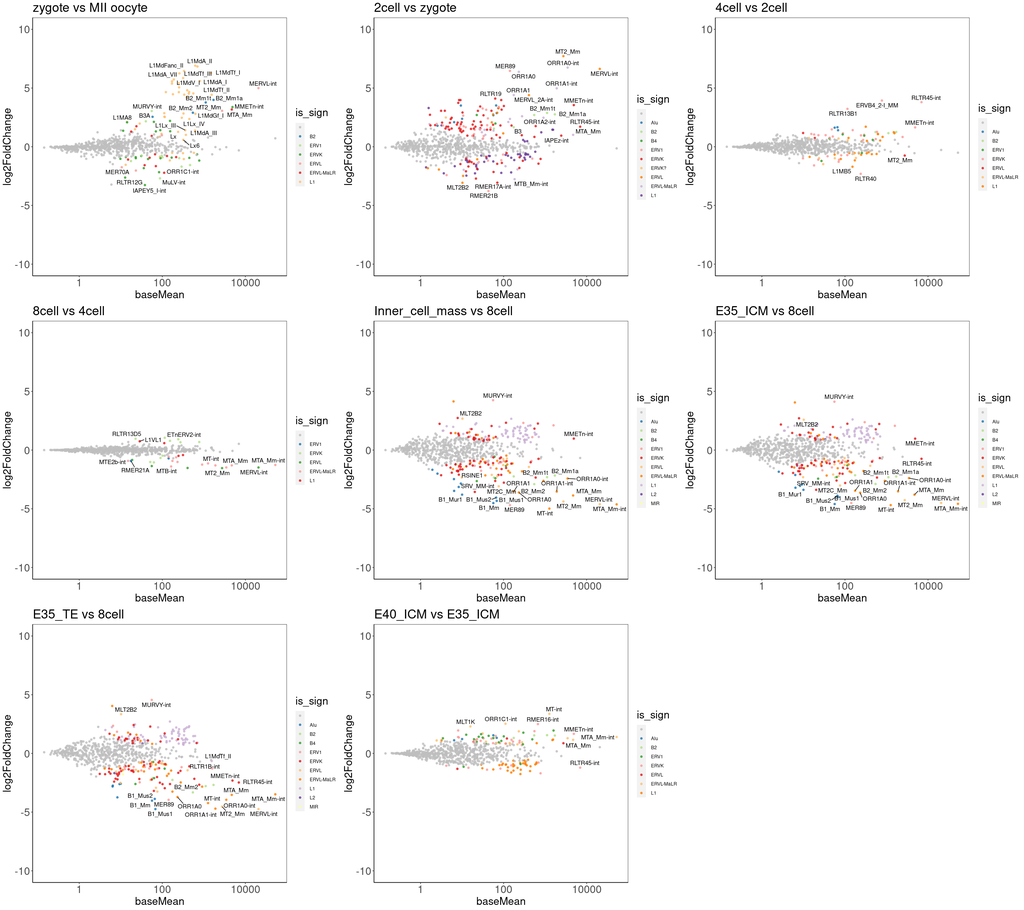

## 3.2 Overlap between morula-to-blastocysts’ DESeq results

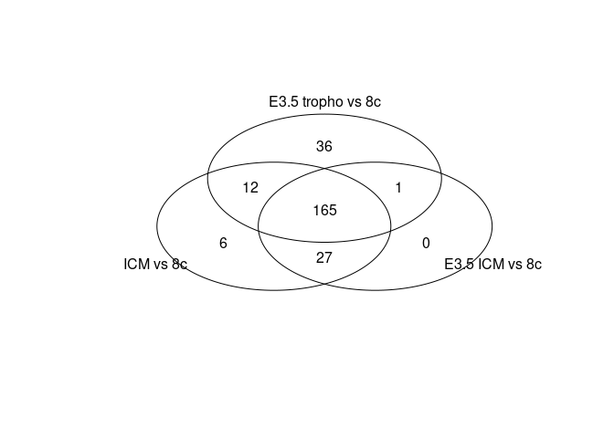

The ICM and E3.5 ICM libraries can be used almost interchangeably, while a significant fraction of DE TEs are specific of ICM or trophectoderm, thus it will be good to combine trophectoderm and ICM DESeq results for comparison with TEs diff. expr. in OgtT931del mutant blastocysts, which are whole embryo samples.